# Narodziny w USA w latach 2000-2014 - analiza eksploracyjna

Aleksandra Jaworska

czerwiec 2022

# Wprowadzenie

Celem projektu jest eksploatacja danych dotyczących narodzin w Stanach Zjednoczonych w latach 2000-2014.

## Obróbka danych

Dane zostały bezpośrednio wczytane z pakietu fivethirtyeight. Zawierają 5479 obseracji i 6 zmiennych.

```r
usb <- US_births_2000_2014
```

## Wykorzystane zmienne

W dalszej analizie wykorzystano następujące zmienne:

| Zmienna | Opis |
| --- | --- |
| *year* | rok urodzenia |
| *month* | miesiąc urodzenia |
| *date_of_month* | dzień urodzenia |
| *date* | dokładna data urodzenia |
| *day_of_week* | skrót dnia tygodnia urodzenia |
| *births* | liczba urodzin przypisanych do danej daty |

Statystyki podsumowujące wybrane zmienne przedstawiają się następująco:

```r
# zamiana niektorych zmiennych na faktory i przypisanie polskich nazw
usb$day_of_week <- factor(usb$day_of_week)
usb$date <- factor(usb$date)
usb$month <- factor(usb$month)
levels(usb$month) <- c("Styczeń", "Luty", "Marzec", "Kwiecień", "Maj", "Czerwiec", "Lipiec", "Sierpień", "Wrzesień", "Październik", "Listopad", "Grudzień")
levels(usb$day_of_week) <- c("Pon", "Wt", "Śr", "Czw", "Pt", "Sob", "Niedz")

# ladna tabelka z podsumowaniem (funkcja kable z pakietu knitr)
knitr::kable(usb %>% select(year, month, date_of_month, date, day_of_week, births) %>% summary)
```

|  | year | month | date_of_month | date | day_of_week | births |
| --- | --- | --- | --- | --- | --- | --- |
|  | Min. :2000 | Styczeń : 465 | Min. : 1.00 | 2000-01-01: 1 | Pon :783 | Min. : 5728 |
|  | 1st Qu.:2003 | Marzec : 465 | 1st Qu.: 8.00 | 2000-01-02: 1 | Wt :783 | 1st Qu.: 8740 |
|  | Median :2007 | Maj : 465 | Median :16.00 | 2000-01-03: 1 | Śr :783 | Median :12343 |
|  | Mean :2007 | Lipiec : 465 | Mean :15.73 | 2000-01-04: 1 | Czw :783 | Mean :11350 |
|  | 3rd Qu.:2011 | Sierpień : 465 | 3rd Qu.:23.00 | 2000-01-05: 1 | Pt :782 | 3rd Qu.:13082 |
|  | Max. :2014 | Październik: 465 | Max. :31.00 | 2000-01-06: 1 | Sob :782 | Max. :16081 |
|  | NA | (Other) :2689 | NA | (Other) :5473 | Niedz:783 | NA |

Z powyższej tabeli można odczyta m.in., że rekordy są kompletne, nie posiadają braków. Co więcej najmniejszą liczbą osób, których narodziny przypisane są do tej samej daty jest 5728, największą 16081, a średni wynik tego zestawienia to 11350. Nieuwzględnione statystyki z powyższej tabeli zostaną szczegółowo omówione w dalszej części analizy.

# Analiza

Przeprowadzona analiza obejmowała następujące zagadnienia:

- analizę czasową - m.in. liczbę urodzin przypisaną do danej daty, dzień, miesiąc i rok narodzin
- analizę przestrzenną - z podziałem na poszczególne dni tygodnia

## Analiza czasowa

Celem tej analizy jest sprawdzenie, czy można zaobserwować jakieś wzorce związane z czasem.

```r
# ramka z danymi pogrupowanymi po roku, policze:
# - ilość osób urodzonych w konkretnym roku z podziałem na lata przestępne
# - wpływ Walentynek (14 luty) na ilość urodzeń (odpowiednio po 9 miesiącach)

usb_year_nbirths <- usb %>% group_by(year) %>%
  summarise(urodzeni = sum(births),
            srednia_urodzen = mean(births),
            max_n_urodzen = max(births),
            min_n_urodzen = min(births),
            n =n()) %>% mutate(czy_przestepny = ifelse(n == 366, "tak", "nie"))
```

### Ilość osób urodzonych w konkretnym roku z podziałem na lata przestępne

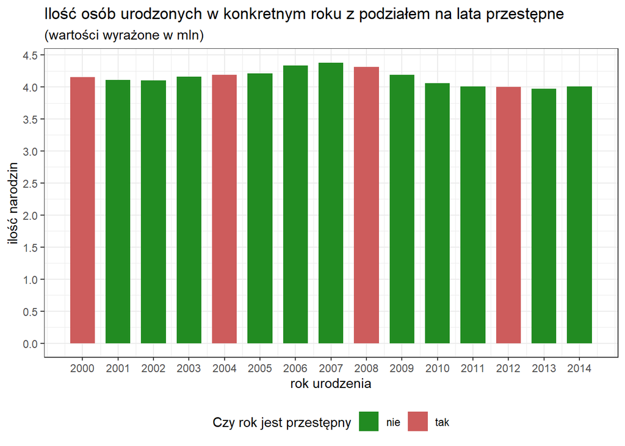

```r
## Ilość osób urodzonych w konkretnym roku z podziałem na lata przestępne

usb_year_nbirths %>% ggplot(aes(x = year, y = urodzeni/1E6)) +
  geom_col(aes(fill = czy_przestepny), width = 0.7) +
  scale_x_continuous(breaks = 2000:2014) +
  scale_y_continuous(breaks = seq(0, 4.5, 0.5)) +
  theme_bw() + theme(legend.position = "bottom") +
  scale_fill_manual(values = c("#228B22", "#CD5C5C")) +
  labs(fill="Czy rok jest przestępny",
       title = "Ilość osób urodzonych w konkretnym roku z podziałem na lata przestępne",
       subtitle = "(wartości wyrażone w mln)",
       x = "rok urodzenia",
       y = "ilość narodzin")
```

### Wpływ Walentynek (14 luty) na ilość urodzeń (odpowiednio po 9 miesiącach)

```r
## Wpływ Walentynek (14 luty) na ilość urodzeń (odpowiednio po 9 miesiącach)

valentines_day_result <- usb %>% group_by(month, date_of_month) %>% summarise(n = sum(births)) %>% mutate(k = ifelse(month == "Listopad" & date_of_month %in% 7:21, "red", "white"))
```

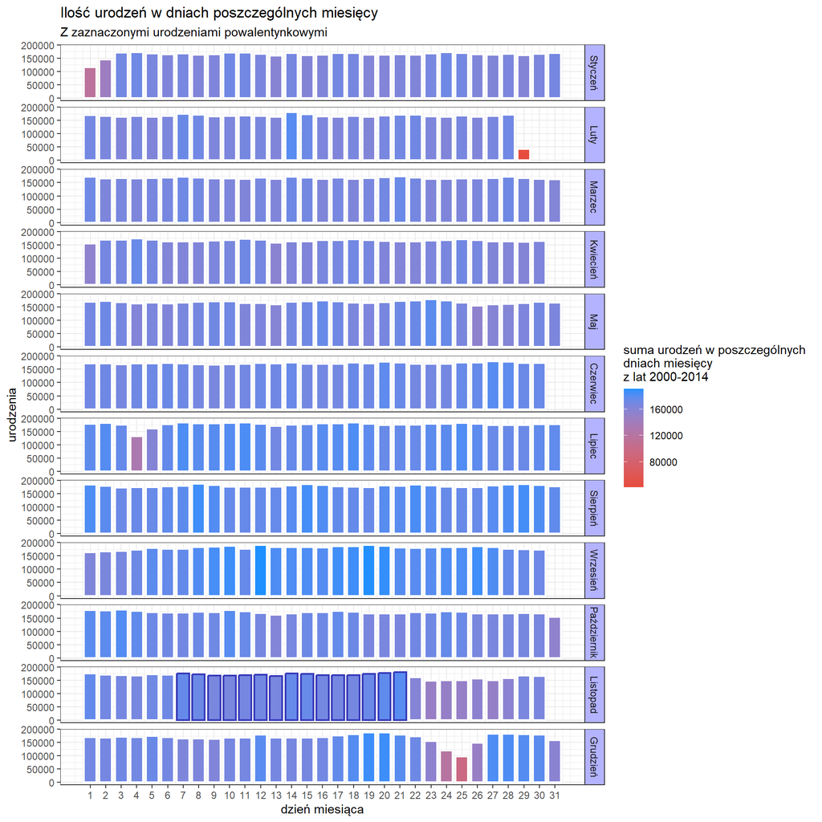

```r
valentines_day_result %>%
  ggplot(aes(x = date_of_month, y = n, fill = n)) + geom_col(aes(col = k), width = 0.8, lwd = 0.8)+ scale_color_manual(values = c("#3639BA", "white"))+
  facet_grid(rows = vars(month))  +
  theme_bw() +  scale_x_continuous(breaks = 1:31) +
  labs(title = "Ilość urodzeń w dniach poszczególnych miesięcy",
       subtitle = "Z zaznaczonymi urodzeniami powalentynkowymi",
       x = "dzień miesiąca",
       y = "urodzenia",
       fill = "suma urodzeń w poszczególnych
dniach miesięcy
z lat 2000-2014") + guides(color = "none") + scale_fill_gradient(low = "#E74C3C", high = "#1E90FF") +
 theme(strip.background = element_rect(fill = alpha('blue', 0.3)))
```

Osoby poczęte 14 lutego szacunkowo powinny urodzić się 14 listopada, jednak dla elastyczności analizy, przedział ten poszerzony został o +/- 7 dni. Jak można zauważyć na wykresie, w podanych przedziałach czasowych nie kreuje się wyraźnie zwiększona tendencja wzrostowa. Świadczy to o tym, iż Walentynki nie mają znaczącego wpływu na wzrost liczby urodzeń.

## Analiza przestrzenna

W tej części opracowania została przeprowadzona analiza z podziałem na miesiące i tygodnie

### Liczba urodzeń z podziałem na miesiące

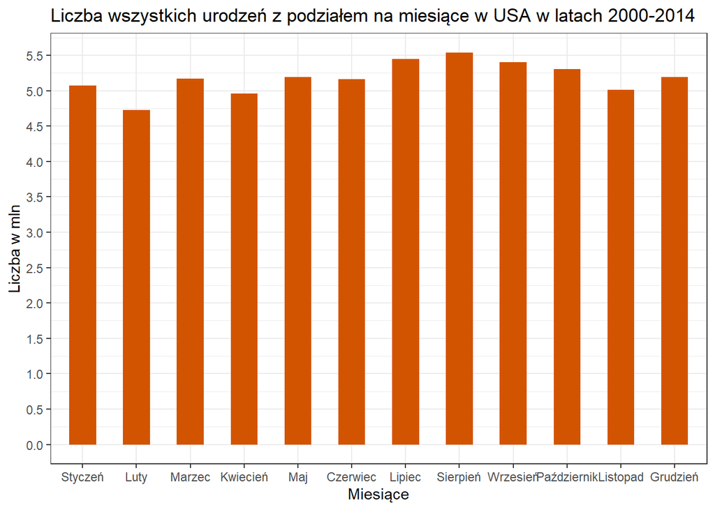

```r
### Liczba urodzeń z podziałem na miesiące ###

usb %>% ggplot(aes(x = month, y = births/1E6)) +
  geom_col(fill = "#D35400", width = 0.5) +
  scale_y_continuous(breaks = seq(0, 6, 0.5)) +
  xlab("Miesiące") +
  ylab("Liczba w mln") +
  ggtitle("Liczba wszystkich urodzeń z podziałem na miesiące w USA w latach 2000-2014") +
  theme_bw()
```

```r
## Tabela pokazująca dokładne wyniki

usb %>% group_by(month) %>%
  summarise(Ilość = sum(births))
```

```
## # A tibble: 12 x 2
##    month         Ilość
##    <fct>         <int>
##  1 Styczeń     5072588
##  2 Luty        4725693
##  3 Marzec      5172961
##  4 Kwiecień    4960750
##  5 Maj         5195445
##  6 Czerwiec    5163360
##  7 Lipiec      5450418
##  8 Sierpień    5540170
##  9 Wrzesień    5399592
## 10 Październik 5302865
## 11 Listopad    5008750
## 12 Grudzień    5194432
```

W wyżej przedstawionym wykresie widać, że nie występuje znaczna różnica liczby urodzeń w każdym z miesięcy, największym wynikiem jest sierpień z liczbą 5540170, natomiast najmniejszą liczbą jest 4725693, które zostało odnotowane w Lutym.

### Liczba urodzeń, w danym dniu tygodnia

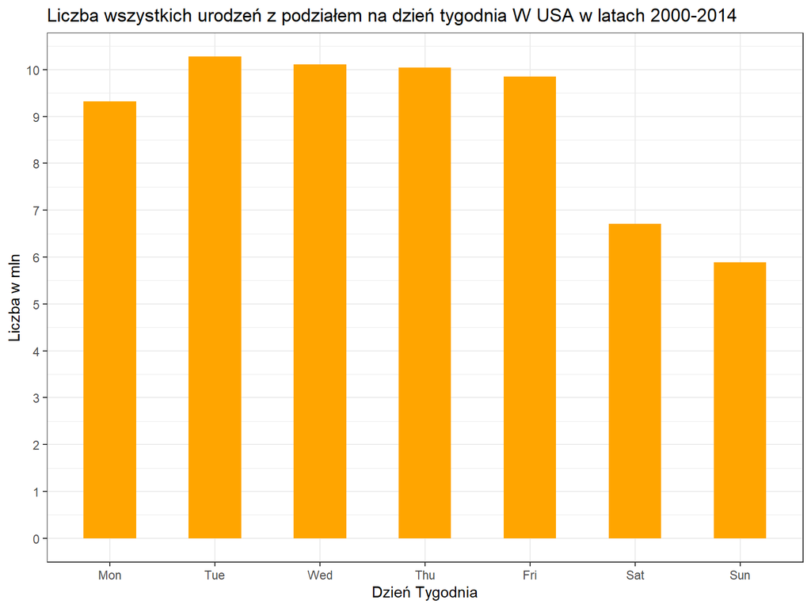

```r
## Liczba urodzeń z podziałem na dzień tygodnia

usb %>% mutate(week.day = wday(date, week_start = 1, label = TRUE, locale = "English")) %>%
        ggplot(aes(x = week.day, y = births/1E6)) +
        geom_col(fill='orange', width = 0.5) +
        scale_y_continuous(breaks = seq(0, 11, 1)) +
        xlab("Dzień Tygodnia") +
        ylab("Liczba w mln") +
        ggtitle("Liczba wszystkich urodzeń z podziałem na dzień tygodnia W USA w latach 2000-2014") +
        theme_bw()
```

```r
## Tabela pokazująca dokładne wyniki

usb %>% mutate(week.day = wday(date, week_start = 1, label = TRUE, locale = "English")) %>%
        group_by(week.day) %>%
        summarise(Ilość = sum(births))
```

```
## # A tibble: 7 x 2
##   week.day    Ilość
##   <ord>       <int>
## 1 Mon       9316001
## 2 Tue      10274874
## 3 Wed      10109130
## 4 Thu      10045436
## 5 Fri       9850199
## 6 Sat       6704495
## 7 Sun       5886889
```

Najwięcej osób urodziło się we wtorek (10274874), najmniej natomiast urodziło się w niedzielę (5886889). Większość dni tygodnia ma zbliżoną do siebie liczbę urodzeń, jednak w weekend, liczba urodzeń jest mniejsza niż w pozostałe dni.